# Lab 1 - Data Analysis and Modeling

Yue Zhang & SiHan Chen

3/25/2025

# Introduction

This lab introduces the basics of R and RStudio. We will work with two built-in datasets, pressure and women, to practice data exploration, visualization, and analysis. We will complete 7 exercises and generate reproducible results in R Markdown format.

# Exercise 1

Task: Complete the R language basics 1_3 from Cookbook for R _ Basics Status: [OK] Done

# Exercise 2 - Exploring the pressure dataset

```r
data(pressure)
head(pressure)
```

|  | temperature | pressure |
| --- | --- | --- |
| 1 | 0 | 0.0002 |
| 2 | 20 | 0.0012 |
| 3 | 40 | 0.0060 |
| 4 | 60 | 0.0300 |
| 5 | 80 | 0.0900 |
| 6 | 100 | 0.2700 |

## Select specific data:

Fourth row, second column:

```r
pressure[4, 2]
```

```
## [1] 0.03
```

Select the entire second column:

```r
pressure[, 2]
```

```
##  [1]   0.0002   0.0012   0.0060   0.0300   0.0900   0.2700   0.7500   1.8500
##  [9]   4.2000   8.8000  17.3000  32.1000  57.0000  96.0000 157.0000 247.0000
## [17] 376.0000 558.0000 806.0000
```

# Exercise 3 - Temperature vs. Pressure Plot

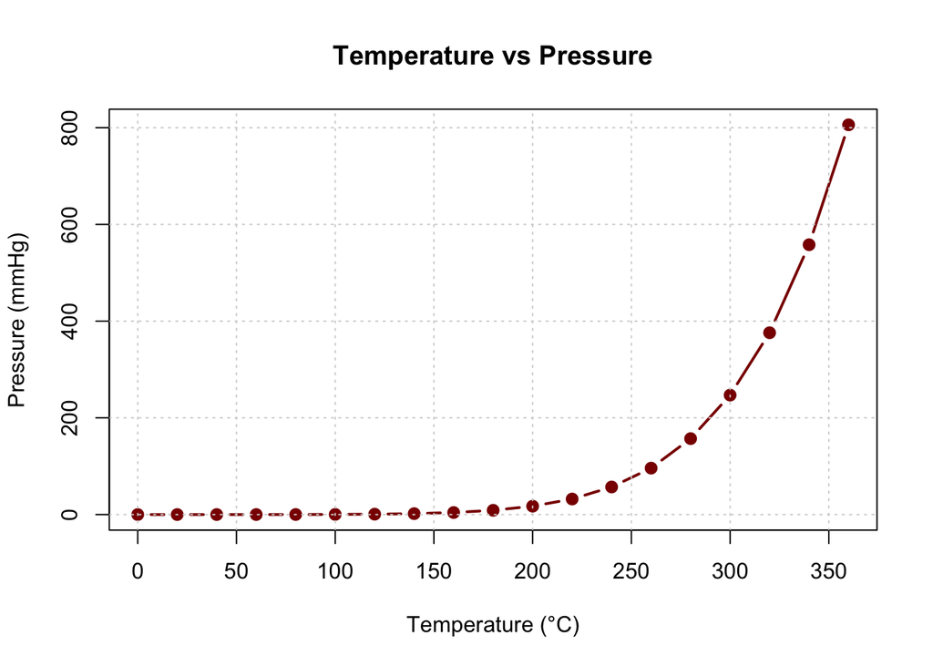

```r
plot(
  x = pressure$temperature,
  y = pressure$pressure,
  type = "b",
  col = "darkred",
  pch = 19,
  lwd = 2,
  xlab = "Temperature (°C)",
  ylab = "Pressure (mmHg)",
  main = "Temperature vs Pressure"
)
grid()
```

From the plot, we observe that as temperature increases, pressure also increases rapidly, showing a non-linear relationship.

# Exercise 4 - Calculating Volume using PV = nRT

We use the ideal gas law:
$$PV =
nRT$$
Where: • ( P ): pressure in Pa • ( T ): temperature in Kelvin • ( V ): volume • ( R = 8.31 ), ( n = 1 )

```r
R <- 8.31
n <- 1
T <- pressure$temperature + 273.15
P <- pressure$pressure * 133.322  # mmHg to Pascal

V <- (n * R * T) / P
```

## Plot: Temperature vs Volume

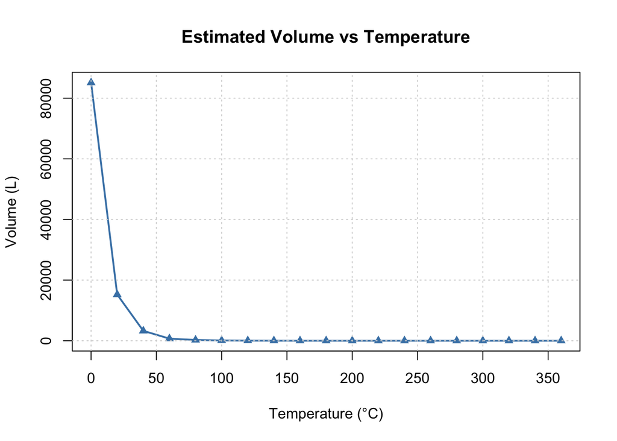

```r
plot(
  x = pressure$temperature, y = V,
  type = "o", col = "steelblue", pch = 17, lwd = 2,
  xlab = "Temperature (°C)", ylab = "Volume (L)",
  main = "Estimated Volume vs Temperature"
)
grid()
```

# Exercise 5 - Exploring the women dataset

```r
data(women)
head(women)
```

|  | height | weight |
| --- | --- | --- |
| 1 | 58 | 115 |
| 2 | 59 | 117 |
| 3 | 60 | 120 |
| 4 | 61 | 123 |
| 5 | 62 | 126 |
| 6 | 63 | 129 |

```r
dim(women)
```

```
## [1] 15  2
```

```r
names(women)
```

```
## [1] "height" "weight"
```

The dataset contains 15 rows and 2 columns: height (inches), weight (lbs)

# Exercise 6 - Plot Height² vs Weight

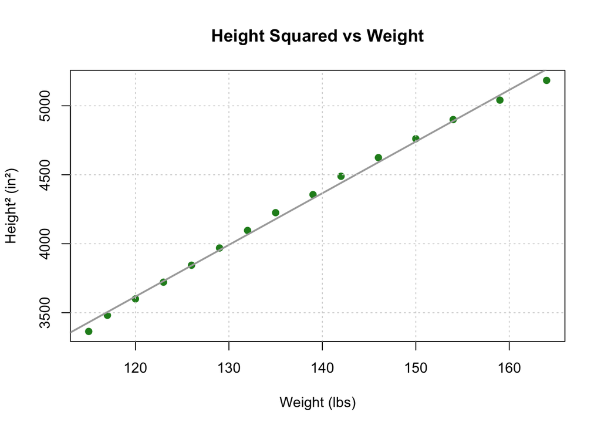

```r
height_sq <- women$height^2

plot(
  x = women$weight, y = height_sq,
  type = "p", pch = 19, col = "forestgreen",
  xlab = "Weight (lbs)", ylab = "Height² (in²)",
  main = "Height Squared vs Weight"
)
abline(lm(height_sq ~ women$weight), col = "darkgray", lwd = 2)
grid()
```

We see a clear upward trend: as weight increases, squared height increases linearly.

# Exercise 7 - BMI Calculation

Formula:
$$\text{BMI} =
\frac{\text{weight (kg)}}{[\text{height (m)}]^2}$$

```r
# Convert units
weight_kg <- women$weight * 0.453592
height_m <- women$height * 0.0254

BMI <- weight_kg / (height_m^2)
BMI
```

```
##  [1] 24.03476 23.63087 23.43563 23.24039 23.04545 22.85107 22.65750 22.46493
##  [9] 22.43494 22.24010 22.19898 22.15088 22.09645 22.17575 22.24215
```

## Plot BMI by individual

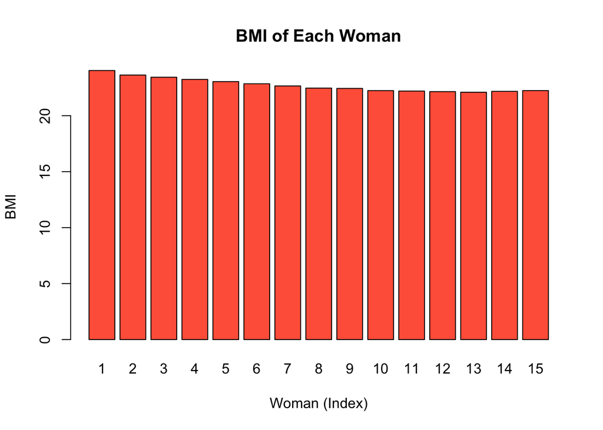

```r
barplot(
  BMI,
  col = "tomato",
  names.arg = 1:15,
  main = "BMI of Each Woman",
  xlab = "Woman (Index)", ylab = "BMI"
)
abline(h = 25, col = "blue", lty = 2)
text(x = which.max(BMI), y = max(BMI) + 1, labels = "Highest", col = "darkred")
```

```r
max_bmi_index <- which.max(BMI)
max_bmi_value <- max(BMI)
list("Index" = max_bmi_index, "Max BMI" = max_bmi_value)
```

```
## $Index
## [1] 1
##
## $`Max BMI`
## [1] 24.03476
```